# Practical Machine Learning

Darci Martin

November 21, 2015

## Summary

We are tasked with building a machine learning algorithm to correctly predict the quality of the exercise from a testing set of activity monitor data.

## Analysis

The training and testing datasets are loaded for analysis.

```r
# download.file("https://d396qusza40orc.cloudfront.net/predmachlearn/pml-training.csv","WLE Dataset/training.csv")
# download.file("https://d396qusza40orc.cloudfront.net/predmachlearn/pml-testing.csv","WLE Dataset/testing.csv")
training <- read.csv("WLE Dataset/training.csv",stringsAsFactors=F,na.strings=c('NA','#DIV/0!',''))
testing <- read.csv("WLE Dataset/testing.csv",stringsAsFactors=F,na.strings=c('NA','#DIV/0!',''))
```

Packages used for analysis are loaded and I am taking a look at the variables in the training dataset. Since the intent is to see what variables impact the classe variable, I want to see if there are any variables I need to eliminate before I create my model.

```r
library(ggplot2)
library(caret)
str(training)
```

```r
filter <- colnames(training[colSums(is.na(training)) < nrow(training) * .8])
filter <- filter[-c(1:7)]
```

Last, I am going to split my training data into a testing/training set in order to cross-validate my final model.

```r
set.seed(1982)
inTrain <- createDataPartition(y=training$classe,p=0.7,list=FALSE)
tr_set <- training[inTrain,filter]
xval_set <- training[-inTrain,filter]
```

Now that I have a set of data for training, I want to look at a plot of the classe to review the distribution.

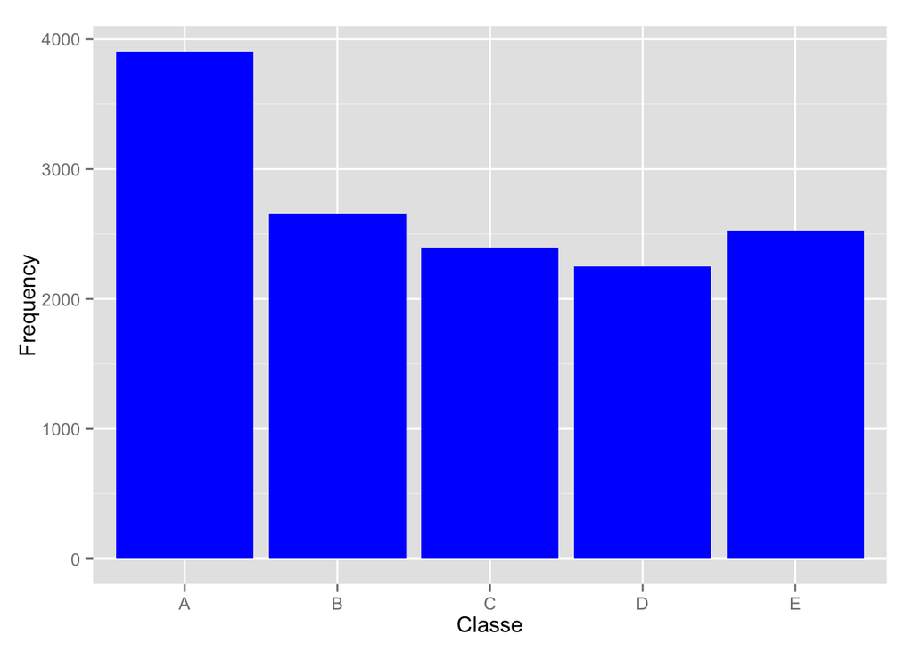

My training set appears evenly distributed among the B-E classe types, and have higher than average incidences of A classe types. It does not appear to be excessively skewed, and I know that I have a considerable amount of observations to draw upon for model building.

## Model Selection

I have chosen to use Random Forest with 10-fold cross-validation. This model was selected because of its reference of high accuracy (98.2% weighted average) within the original research experiment.

```r
library(plyr)
library(doMC)
doMC::registerDoMC(cores=2)
```

```r
modfit <- train(classe~.,data=tr_set,method="rf",trControl=trainControl(method="cv",number=10), prox=TRUE,allowParallel=TRUE)
```

[output not shown]

The model produces a predicted out of sample error of 0.64% which is extremely acceptable. I am going to proceed with testing my cross-validation set.

```
## Confusion Matrix and Statistics
##
##           Reference
## Prediction    A    B    C    D    E
##          A 1672   10    0    0    0
##          B    2 1128    5    0    0
##          C    0    1 1014   10    2
##          D    0    0    7  953    5
##          E    0    0    0    1 1075
##
## Overall Statistics
##
##                Accuracy : 0.9927
##                  95% CI : (0.9902, 0.9947)
##     No Information Rate : 0.2845
##     P-Value [Acc > NIR] : < 2.2e-16
##
##                   Kappa : 0.9908
##  Mcnemar's Test P-Value : NA
##
## Statistics by Class:
##
##                      Class: A Class: B Class: C Class: D Class: E
## Sensitivity            0.9988   0.9903   0.9883   0.9886   0.9935
## Specificity            0.9976   0.9985   0.9973   0.9976   0.9998
## Pos Pred Value         0.9941   0.9938   0.9873   0.9876   0.9991
## Neg Pred Value         0.9995   0.9977   0.9975   0.9978   0.9985
## Prevalence             0.2845   0.1935   0.1743   0.1638   0.1839
## Detection Rate         0.2841   0.1917   0.1723   0.1619   0.1827
## Detection Prevalence   0.2858   0.1929   0.1745   0.1640   0.1828
## Balanced Accuracy      0.9982   0.9944   0.9928   0.9931   0.9967
```

Based on the confusion matrix, I expect that the out of sample error will be 1-0.9927 = 0.73%

The following plot shows the results of the model performed on the cross-validation set. Very few predictions fall outside of the reference set.

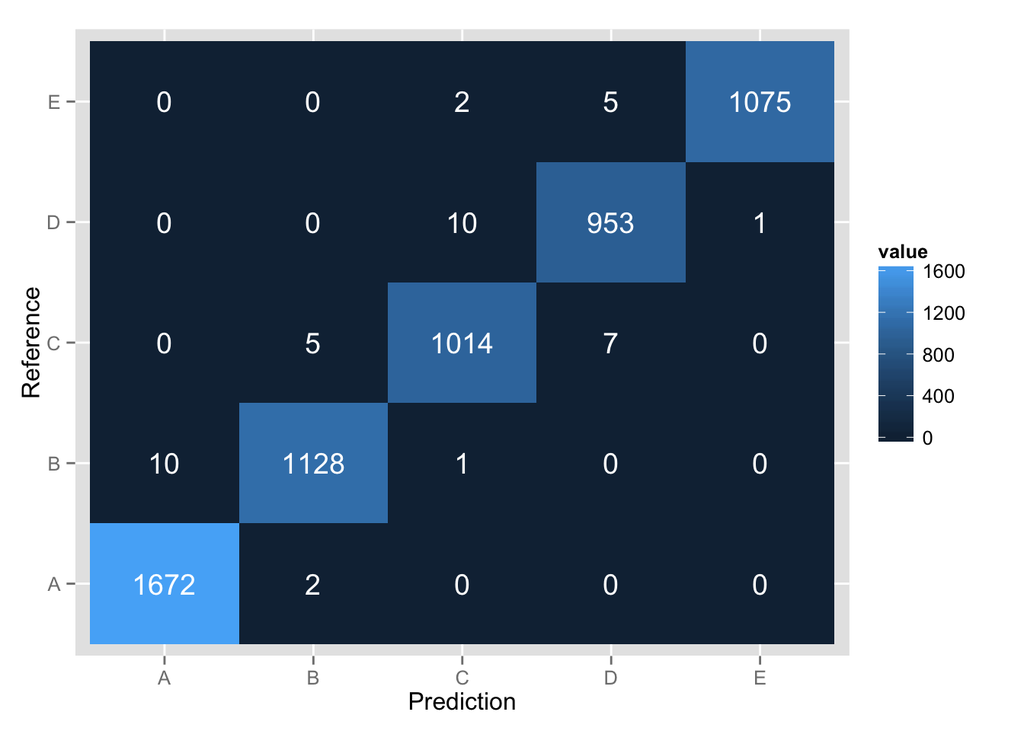

## Final Submission

Last, I apply my random forest algorithm to the testing set for submission.

```r
names(testing)[160] <- "classe"
final_set <- testing[,filter]
answers <- predict(modfit,final_set)
answers <- as.character(answers)
```